# MasterDoc

Nora Otic

2025-06-19

# Group 4 Data Analysis Project

# Silent Signals:

# Projekt Overview

## Steps

- 1. data exploration (Nora)
- 2. data normalisation (Ellinor, Laura, Zoe)
- 3. shift analysis (Ellinor, Laura, Nora)
- 4. dimension reduction (Zoe)
- 5. detection of features predictive of RNA-binding (Ellinor, Laura)

## libraries

- limma
- pheatmap
- sva
- stringr
- emdist
- DT
- tidyr
- ggplot2
- dplyr
- shiny
- cluster
- factoextra
- scatterplot3d
- plotly

# load data

```r
#load dataset
url <- "https://hub.dkfz.de/s/QT3BfRperQqMxPF/download/RDeeP_A549_NS.csv.zip"


#Create a temporary file and download the ZIP
temp_file <- tempfile()
download.file(url, temp_file)
zip_contents <- unzip(temp_file, list = TRUE)

csv_file <- unzip(temp_file, files = zip_contents$Name[1], exdir = tempdir())
A549_NS <- read.csv(csv_file, sep = ";")
```

# 1. data exploration (Nora)

```r
#number of rows and columns
nrow(A549_NS)
```

```
## [1] 3680
```

```r
ncol(A549_NS)
```

```
## [1] 151
```

```r
#type of data (überprüft die class der Spalten -> alle Eintrage haben zwangsweise dieselbe class)
sum(sapply(A549_NS, is.numeric))
```

```
## [1] 150
```

```r
#finding NAs
sum(is.na(A549_NS))
```

```
## [1] 0
```

```r
# all columns
col_names <- colnames(A549_NS)

# identify rnase and control columns
ctrl_cols <- c("Protein_Name", grep("Ctrl", col_names, value = TRUE))
rnase_cols <- c("Protein_Name", grep("RNase", col_names, value = TRUE))

# create dataframe
df_ctrl <- A549_NS[, ctrl_cols, drop = FALSE]
df_rnase <- A549_NS[, rnase_cols, drop = FALSE]
```

# Reproducability

Goal: evaluate the consistency of the measured replicates across the fractions for both treatments to determine the reproducability ## Reproducibility of ctrl values

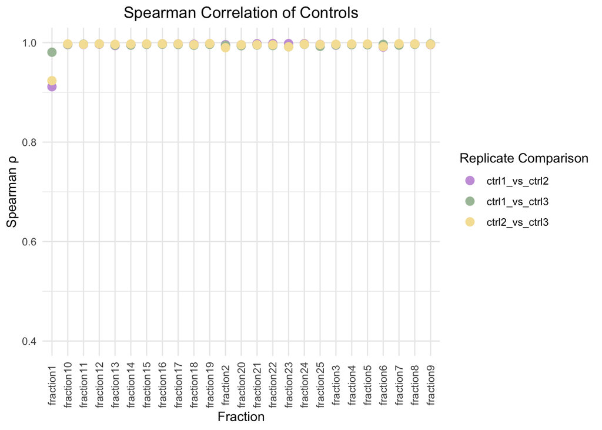

```r
# Reproducabilty of control measurements
# create dataframe for analysis of the replicates
ctrl_correlations <- data.frame(
  fraction = character(),
  ctrl1_vs_ctrl2 = numeric(),
  ctrl1_vs_ctrl3 = numeric(),
  ctrl2_vs_ctrl3 = numeric(),
  stringsAsFactors = FALSE
)

# loop over all fractions and calculate spearman correlation
for (i in 0:24) {
  start_col <- 2 + i * 3
  end_col <- start_col + 2
  ctrl_data <- df_ctrl[, start_col:end_col]
  colnames(ctrl_data) <- c("ctrl1", "ctrl2", "ctrl3")
  cor_matrix <- cor(ctrl_data, use = "pairwise.complete.obs", method = "spearman")
  ctrl_correlations <- rbind(ctrl_correlations, data.frame(
    fraction = paste0("fraction", i + 1),
    ctrl1_vs_ctrl2 = cor_matrix["ctrl1", "ctrl2"],
    ctrl1_vs_ctrl3 = cor_matrix["ctrl1", "ctrl3"],
    ctrl2_vs_ctrl3 = cor_matrix["ctrl2", "ctrl3"]
  ))
}


library(ggplot2)
library(tidyr)

ctrl_cor_long <- pivot_longer(ctrl_correlations,
                               cols = starts_with("ctrl"),
                               names_to = "comparison",
                               values_to = "correlation")

# Plot
ggplot(ctrl_cor_long, aes(x = fraction, y = correlation, color = comparison)) +
  geom_point(size = 3) +
  scale_color_manual(values = c(
    "ctrl1_vs_ctrl2" = "#c9a0dc",
    "ctrl1_vs_ctrl3" = "#A9C1A6",
    "ctrl2_vs_ctrl3" = "#F5E1A4"
  )) +
  ylim(0.4, 1) +
  theme_minimal() +
  labs(title = "Spearman Correlation of Controls",
       y = "Spearman ρ",
       x = "Fraction",
       color = "Replicate Comparison") +
  theme(axis.text.x = element_text(angle = 90, vjust = 0.5),
        plot.title = element_text(hjust = 0.5))
```

Output: very high correlation across the fractions shows reproducability for the control measurments -> all above 0.8

## Reproducibility of rnase values

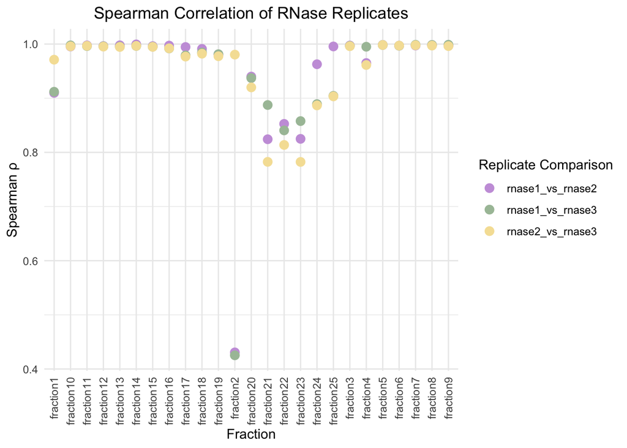

```r
# Reproducabilty of rnase measurements
# create dataframe for analysis of the replicates
rnase_correlations <- data.frame(
  fraction = character(),
  rnase1_vs_rnase2 = numeric(),
  rnase1_vs_rnase3 = numeric(),
  rnase2_vs_rnase3 = numeric(),
  stringsAsFactors = FALSE
)

# loop over all fractions and calculate the spearman correlation
for (i in 0:24) {
  start_col <- 2 + i * 3
  end_col <- start_col + 2
  rnase_data <- df_rnase[, start_col:end_col]
  colnames(rnase_data) <- c("rnase1", "rnase2", "rnase3")
  cor_matrix <- cor(rnase_data, use = "pairwise.complete.obs", method = "spearman")
  rnase_correlations <- rbind(rnase_correlations, data.frame(
    fraction = paste0("fraction", i + 1),
    rnase1_vs_rnase2 = cor_matrix["rnase1", "rnase2"],
    rnase1_vs_rnase3 = cor_matrix["rnase1", "rnase3"],
    rnase2_vs_rnase3 = cor_matrix["rnase2", "rnase3"]
  ))
}

rnase_cor_long <- pivot_longer(rnase_correlations,
                                cols = starts_with("rnase"),
                                names_to = "comparison",
                                values_to = "correlation")

# Plot
ggplot(rnase_cor_long, aes(x = fraction, y = correlation, color = comparison)) +
  geom_point(size = 3) +
  scale_color_manual(values = c(
    "rnase1_vs_rnase2" = "#c9a0dc",
    "rnase1_vs_rnase3" = "#A9C1A6",
    "rnase2_vs_rnase3" = "#F5E1A4"
  )) +
  theme_minimal() +
  labs(title = "Spearman Correlation of RNase Replicates",
       y = "Spearman ρ",
       x = "Fraction",
       color = "Replicate Comparison") +
  theme(axis.text.x = element_text(angle = 90, vjust = 0.5, hjust = 1),
        plot.title = element_text(hjust = 0.5))
```

Output: correlation amongst the rnase values is sporadically lower compared to the ctrl measurments, still within an acceptable range -> threshold for acceptable values at 0.35 -> evaluation is therefore reproducable as well

# 2. data normalisation

## normalisation (Ellinor, Laura)

### normalisation per fraction

Goal: receive basis for subsequent normalisation #### determine columnwise mean

```r
# function to compute mean columnwise (except Protein_Name)
compute_column_means <- function(df) {
  # select numeric columns (except Protein_Name)
  numeric_data <- df[, sapply(df, is.numeric)]

  # calculate mean coulmnwise
  col_means <- colMeans(numeric_data, na.rm = TRUE)

  return(col_means)
}

#apply to our data
ctrl_means <- compute_column_means(df_ctrl)
rnase_means <- compute_column_means(df_rnase)


# save means as dataframes
ctrl_means_df <- data.frame(Sample = names(ctrl_means), Mean = as.numeric(ctrl_means))
rnase_means_df <- data.frame(Sample = names(rnase_means), Mean = as.numeric(rnase_means))

#check whether there are means == 0 (to calculate normalization factor: mean are denominator -> would create NAs if mean were 0)
sum(ctrl_means_df[, 2] == 0)
```

```
## [1] 0
```

```r
sum(rnase_means_df[, 2]==0)
```

```
## [1] 0
```

### normalisation factor

Goal: Calculate reference values per fraction by computing the mean of the two most similar replicates (out of three) to serve as normalization basis.

```r
# create function to calculate the mean of the two most similar replicates (out of three replicates)
mean_of_closest_pair <- function(x) {
  combs <- combn(x, 2)                          # all pairwise combinations
  diffs <- abs(combs[1, ] - combs[2, ])         # calculates the absolute distance
  min_idx <- which.min(diffs)                   # indices of minimal distance replicates
  mean(combs[, min_idx])                        # mean of the most similar pair
}

# alter function so it will be applied to three values at a time moving fractionwise
process_blocks <- function(values_vector) {
  n_blocks <- length(values_vector) / 3         # number of fractions
  result <- numeric(n_blocks)

  for (i in 1:n_blocks) {
    block <- values_vector[((i - 1) * 3 + 1):(i * 3)] #values vector contains the three values of the replicates for each fraction
    result[i] <- mean_of_closest_pair(block)
  }

  return(result)
}

# extract values from the dataframe
control_values <- ctrl_means_df$Mean
rnase_values   <- rnase_means_df$Mean

# apply to our data
control_means <- process_blocks(control_values)
rnase_means   <- process_blocks(rnase_values)

# save result as dataframe
closest_means_ctrl <- data.frame(
  Fraktion = paste0("Fraction", 1:length(control_means)),
  Control_most_similar_pair_mean  = control_means
)

closest_means_rnase <- data.frame(
  Fraktion = paste0("Fraction", 1:length(control_means)),
  RNase_most_similar_pair_mean = rnase_means)
```

#### create normalisation matrix

Goal: Create normalization factors for each replicate by dividing the reference mean by the replicate value.

```r
n_fractions <- 25
n_replicates <- 3

# ctrl_means_df and rnase_means_df contain all replicate means in one column, e.g. 'Mean'
# ctrl_final_means_df and rnase_final_means_df contain one final mean per fraction in 'FinalMean'

# create matrices for replicates of each fraction (25 rows × 3 columns)
ctrl_mat <- matrix(ctrl_means_df$Mean, nrow = n_fractions, ncol = n_replicates, byrow = TRUE)
rnase_mat <- matrix(rnase_means_df$Mean, nrow = n_fractions, ncol = n_replicates, byrow = TRUE)

# initialize normalization matrices with NA values
norm_ctrl_mat <- matrix(NA, nrow = n_fractions, ncol = n_replicates)
norm_rnase_mat <- matrix(NA, nrow = n_fractions, ncol = n_replicates)

# loop over all fractions to calculate normalization factors
for (r in 1:n_fractions) {
  control_values <- ctrl_mat[r, ]  # 3 replicates for Control
  rnase_values <- rnase_mat[r, ]   # 3 replicates for RNase

  # retrieve FinalMean from control and RNase data frames
  mean_control <- closest_means_ctrl[r, 2]
  mean_rnase <- closest_means_rnase[r, 2]

  # ensure exactly one value per fraction
  if(length(mean_control) != 1 | length(mean_rnase) != 1) {
    stop(paste("More or less than one FinalMean found for fraction", r))
  }

  # calculate normalization factors by dividing final mean by replicate values
  norm_ctrl_mat[r, ] <- mean_control / control_values
  norm_rnase_mat[r, ] <- mean_rnase / rnase_values
}

# check for any NAs in normalization matrices
sum(is.na(norm_ctrl_mat))
```

```
## [1] 0
```

```r
sum(is.na(norm_rnase_mat))
```

```
## [1] 0
```

#### Apply Normalisation Matrix to Data

Goal: Compensate deviations between replicates and the reference value by multiplying with normalisation factors

```r
normalize_df <- function(df, norm_mat) {
  # Extract numeric data excluding the first column ("Protein_Name")
  data_mat <- as.matrix(df[, -1])

  # Get the number of blocks (rows) and columns per block from normalization matrix
  n_blocks <- nrow(norm_mat)
  cols_per_block <- ncol(norm_mat)

  # Apply normalization blockwise:
  # The normalization matrix is iterated column-wise and applied in this order to the columns of the original data
  for (i in 1:n_blocks) {
    for (j in 1:cols_per_block) {
      col_index <- (i - 1) * cols_per_block + j
      data_mat[, col_index] <- data_mat[, col_index] * norm_mat[i, j]
    }
  }

  # Combine Protein_Name column with normalized data and return as a dataframe
  result_df <- cbind(Protein_Name = df$Protein_Name, as.data.frame(data_mat))
  return(result_df)
}

# Apply normalization to control and RNase dataframes
normed_ctrl_df  <- normalize_df(df_ctrl, norm_ctrl_mat)
normed_rnase_df <- normalize_df(df_rnase, norm_rnase_mat)
```

### Moving Average Filter & Sorting Data

Goal: Apply a moving average filter (window = 3) across fractions to smooth intensity values. -> Smoothing is applied per replicate and protein; first and last fraction values are kept unchanged. -> The resulting dataframe is then reordered: columns are grouped by fraction (not by replicate).

```r
# Mean filter function for a row (preserving first and last value)
smooth_and_reorder <- function(df, n_fractions = 25, n_replicates = 3) {
  proteins <- df[, 1]

  smoothed_reps <- lapply(1:n_replicates, function(rep) {
    cols <- seq(1 + rep, 1 + rep + (n_fractions - 1) * 3, by = 3)
    rep_data <- df[, cols]

    smoothed_data <- matrix(NA, nrow = nrow(rep_data), ncol = n_fractions)
    smoothed_data[, 1] <- rep_data[, 1]
    smoothed_data[, n_fractions] <- rep_data[, n_fractions]

    for (i in 2:(n_fractions - 1)) {
      smoothed_data[, i] <- rowMeans(rep_data[, (i - 1):(i + 1)], na.rm = TRUE)
    }

    smoothed_df <- as.data.frame(smoothed_data)
    colnames(smoothed_df) <- paste0("Fraction", 1:n_fractions, "_Rep", rep)
    smoothed_df
  })

  combined_df <- do.call(cbind, smoothed_reps)

  # sort columns: first all replicates of first fraction, then fraction 2, etc.
  sorted_cols <- unlist(lapply(1:n_fractions, function(frac) {
    paste0("Fraction", frac, "_Rep", 1:n_replicates)
  }))

  final_df <- cbind(Protein = proteins, combined_df[, sorted_cols])
  return(final_df)
}

# apply to our data
final_smoothed_ctrl <- smooth_and_reorder(normed_ctrl_df)
final_smoothed_rnase <- smooth_and_reorder(normed_rnase_df)

#check if any NAs were created
sum(is.na(final_smoothed_ctrl))
```

```
## [1] 0
```

```r
sum(is.na(final_smoothed_rnase))
```

```
## [1] 0
```

#### checking for replicates with rowsum == 0

```r
# check for any rows with rowSum == 0 (per replicate)
check_zero_replicates_detailed <- function(df) {
  # Remove first column (protein names)
  data_only <- df[, -1]
  protein_names <- df[, 1]

  # Initialize lists to store results
  zero_count <- integer(nrow(data_only))
  zero_replicates <- character(nrow(data_only))

  # Loop through each row (protein)
  for (i in 1:nrow(data_only)) {
    affected_reps <- c()  # Temporary holder for replicate names

    for (rep in 1:3) {
      # Select columns for this replicate across all fractions
      replicate_indices <- seq(from = rep, to = ncol(data_only), by = 3)

      # Calculate sum for this replicate
      rep_sum <- sum(data_only[i, replicate_indices])

      # If sum is zero, store the replicate name
      if (rep_sum == 0) {
        affected_reps <- c(affected_reps, paste0("Replicate", rep))
      }
    }

    # Store number of zero replicates and their names
    zero_count[i] <- length(affected_reps)
    zero_replicates[i] <- if (length(affected_reps) > 0) paste(affected_reps, collapse = ", ") else NA
  }

  # Create final summary data frame
  summary_df <- data.frame(
    Protein = protein_names,
    Zero_Replicate_Count = zero_count,
    Affected_Replicates = zero_replicates,
    stringsAsFactors = FALSE
  )

  # Optional: filter to only those with at least one zero replicate
  summary_df <- summary_df[summary_df$Zero_Replicate_Count > 0, ]

  return(summary_df)
}

# Run for control
ctrl_zero_summary <- check_zero_replicates_detailed(final_smoothed_ctrl)

# Run for RNase
rnase_zero_summary <- check_zero_replicates_detailed(final_smoothed_rnase)
```

## Normalisation of Total Amount per Replicate to 100%

Goal: Obtain normalized values per replicate

```r
#normalize total amount per replicate to 100%
calc_fraction_percentages <- function(df, zero_info, n_fractions = 25, n_replicates = 3) {
  proteins <- df[, 1]
  percent_reps <- list()

  for (rep in 1:n_replicates) {
    # Select replicate columns for all fractions (e.g., Rep1 of all fractions)
    cols <- seq(1 + rep, 1 + rep + (n_fractions - 1) * 3, by = 3)
    rep_data <- as.matrix(df[, cols])

    # Get logical vector: TRUE if replicate sum == 0 (should NOT be normalized)
    rep_name <- paste0("Replicate", rep)
    skip_replicate <- zero_info[[rep_name]] == TRUE  # original values are kept


    # Calculate row sums
    row_sums <- rowSums(rep_data, na.rm = TRUE)

    # Normalize only where rowSum != 0
    percent_data <- rep_data  # start with original values

    # Normalize where allowed (i.e., rowSum != 0)
    normalize_rows <- !skip_replicate
    percent_data[normalize_rows, ] <- sweep(
      rep_data[normalize_rows, ],
      1,
      row_sums[normalize_rows],
      FUN = "/"
    ) * 100

    # Create dataframe and set column names
    percent_df <- as.data.frame(percent_data)
    colnames(percent_df) <- paste0("Fraction", 1:n_fractions, "_Rep", rep)
    percent_reps[[rep]] <- percent_df
  }

  # Combine all replicate dataframes
  combined_percent_df <- do.call(cbind, percent_reps)

  # Reorder columns: Fraction1_Rep1, Fraction1_Rep2, Fraction1_Rep3, etc.
  sorted_cols <- unlist(lapply(1:n_fractions, function(frac) {
    paste0("Fraction", frac, "_Rep", 1:n_replicates)
  }))

  final_percent_df <- cbind(Protein = proteins, combined_percent_df[, sorted_cols])
  return(final_percent_df)
}


# Run the replicate-zero check
ctrl_zero_info <- check_zero_replicates_detailed(final_smoothed_ctrl)
rnase_zero_info <- check_zero_replicates_detailed(final_smoothed_rnase)

# Run the adjusted percentage calculation
percent_ctrl_df <- calc_fraction_percentages(final_smoothed_ctrl, ctrl_zero_info)
percent_rnase_df <- calc_fraction_percentages(final_smoothed_rnase, rnase_zero_info)

#check for NAs
sum(is.na(percent_ctrl_df))
```

```
## [1] 0
```

```r
sum(is.na(percent_rnase_df))
```

```
## [1] 0
```

## Calculate Mean Over the Three Replicates per Fraction

Goal: Obtain normalized values averaged across replicates to get average distribution per fraction

```r
calculate_mean_per_fraction <- function(df, n_fractions = 25, n_replicates = 3) {
  proteins <- df[, 1]  # Protein-Names
  data_only <- df[, -1]  # only numeric values

  mean_matrix <- matrix(NA, nrow = nrow(data_only), ncol = n_fractions)

  for (f in 1:n_fractions) {
    # columns for fraction f (3 replicates each)
    cols <- ((f - 1) * n_replicates + 1):(f * n_replicates)
    mean_matrix[, f] <- rowMeans(data_only[, cols], na.rm = TRUE)
  }

  # save result as dataframe
  mean_df <- as.data.frame(mean_matrix)
  colnames(mean_df) <- paste0("Fraction", 1:n_fractions)
  final_df <- cbind(Protein = proteins, mean_df)

  return(final_df)
}

#apply to our data
mean_ctrl_df <- calculate_mean_per_fraction(percent_ctrl_df)
mean_rnase_df <- calculate_mean_per_fraction(percent_rnase_df)

#check if NAs were created
sum(is.na(mean_ctrl_df))
```

```
## [1] 0
```

```r
sum(is.na(mean_rnase_df))
```

```
## [1] 0
```

## Normalisation of Amount of Protein to Equal 100%

Goal: Obtain comparable relative distributions of protein amounts across fractions

```r
# normalization of amount of protein to equal 100%

calculate_fraction_percentages <- function(mean_df) {
  proteins <- mean_df[, 1]
  data_only <- mean_df[, -1]

  # calculate row sum (sum across all fractions for each protein)
  row_totals <- rowSums(data_only, na.rm = TRUE)

  # transform amount into percent
  percent_matrix <- sweep(data_only, 1, row_totals, FUN = "/") * 100

  # combine result to a dataframe
  percent_df <- cbind(Protein = proteins, as.data.frame(percent_matrix))
  colnames(percent_df) <- colnames(mean_df)

  return(percent_df)
}


# apply to our data
normalized_ctrl_df  <- calculate_fraction_percentages(mean_ctrl_df)
normalized_rnase_df <- calculate_fraction_percentages(mean_rnase_df)

#check if any NAs were created
sum(is.na(normalized_ctrl_df))
```

```
## [1] 0
```

```r
sum(is.na(normalized_rnase_df))
```

```
## [1] 0
```

## Check for Empty Protein Distributions After Normalization

Goal: Identify proteins with zero total abundance after normalization

```r
# For Control data
# Calculate row sums excluding the first column ("Protein_Name")
row_sums_ctrl <- rowSums(normalized_ctrl_df[, -1])

# Create a boolean vector: TRUE where row sum equals zero
rows_with_zero_sum_ctrl <- row_sums_ctrl == 0

# Check if any rows have a sum of zero
any(rows_with_zero_sum_ctrl)
```

```
## [1] FALSE
```

```r
# For RNase data
# Calculate row sums excluding the first column ("Protein_Name")
row_sums_rnase <- rowSums(normalized_rnase_df[, -1])

# Create a boolean vector: TRUE where row sum equals zero
rows_with_zero_sum_rnase <- row_sums_rnase == 0

# Check if any rows have a sum of zero
any(rows_with_zero_sum_rnase)
```

```
## [1] FALSE
```

# Visualization of the distribution of any protein before and after rnase treatment

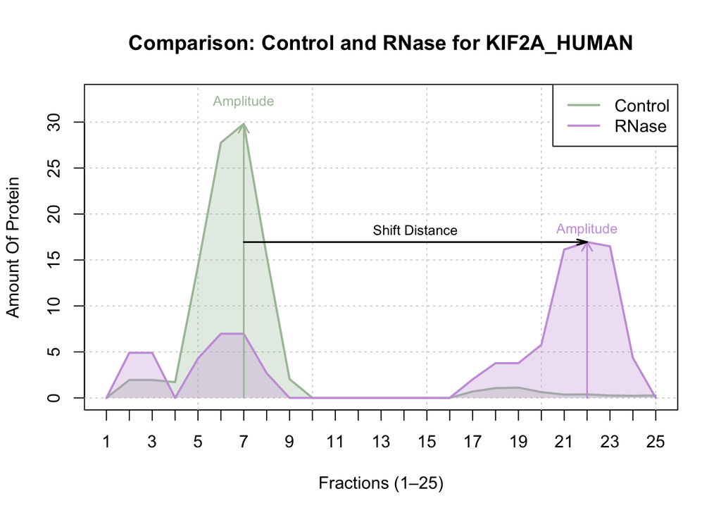

```r
# choose a protein and extract data across the fractions
protein_id <- "KIF2A_HUMAN"
protein_row <- which(normalized_ctrl_df[, 1] == protein_id)
intensities_ctrl <- as.numeric(normalized_ctrl_df[protein_row, 2:26])
intensities_rnase <- as.numeric(normalized_rnase_df[protein_row, 2:26])
fraktionen <- 1:25

# prepare the plot
plot(fraktionen, intensities_ctrl, type = "n",
     xlab = "Fractions (1–25)", ylab = "Amount Of Protein",
     main = paste("Comparison: Control and RNase for", protein_id),
     ylim = c(0, max(c(intensities_ctrl, intensities_rnase)) * 1.1),
     xaxt = "n")
axis(1, at = 1:25)
grid(col = "lightgray", lty = "dotted")

hex_to_rgba <- function(hex_code, alpha = 1) {
  hex_code_clean <- substring(hex_code, 2)
  r <- strtoi(substr(hex_code_clean, 1, 2), 16L) / 255
  g <- strtoi(substr(hex_code_clean, 3, 4), 16L) / 255
  b <- strtoi(substr(hex_code_clean, 5, 6), 16L) / 255
  rgb(r, g, b, alpha)
}

ctrl_fill_color <- hex_to_rgba("#A9C1A6", 0.3)
ctrl_line_color <- hex_to_rgba("#A9C1A6", 1)
rnase_fill_color <- hex_to_rgba("#c9a0dc", 0.3)
rnase_line_color <- hex_to_rgba("#c9a0dc", 1)


# control graph
polygon(c(fraktionen, rev(fraktionen)),
        c(rep(0, length(fraktionen)), rev(intensities_ctrl)),
        col = ctrl_fill_color, border = NA)
lines(fraktionen, intensities_ctrl, col = ctrl_line_color, lwd = 2)

# rnase graph
polygon(c(fraktionen, rev(fraktionen)),
        c(rep(0, length(fraktionen)), rev(intensities_rnase)),
        col = rnase_fill_color, border = NA)
lines(fraktionen, intensities_rnase, col = rnase_line_color, lwd = 2)

legend("topright",
       legend = c("Control", "RNase"),
       col = c(ctrl_line_color, rnase_line_color),
       lwd = 2,
       bg = "white")


# visualize arrows for better depiction of the shift
# find the global maxima
max_ctrl_idx <- which.max(intensities_ctrl)
max_ctrl_val <- intensities_ctrl[max_ctrl_idx]
max_rnase_idx <- which.max(intensities_rnase)
max_rnase_val <- intensities_rnase[max_rnase_idx]

# add arrows for the amplitude of the maxima
arrows(x0 = fraktionen[max_ctrl_idx], y0 = 0,
       x1 = fraktionen[max_ctrl_idx], y1 = max_ctrl_val,
       col = ctrl_line_color, lwd = 1.5, length = 0.1)

arrows(x0 = fraktionen[max_rnase_idx], y0 = 0,
       x1 = fraktionen[max_rnase_idx], y1 = max_rnase_val,
       col = rnase_line_color, lwd = 1.5, length = 0.1)

text(fraktionen[max_ctrl_idx], max_ctrl_val + 0.08 * max_ctrl_val,
     labels = "Amplitude", col = ctrl_line_color, cex = 0.8)

text(fraktionen[max_rnase_idx], max_rnase_val + 0.08 * max_rnase_val,
     labels = "Amplitude", col = rnase_line_color, cex = 0.8)

# improved position of the arrow
arrow_y <- min(max_ctrl_val, max_rnase_val)

# shift distance arrow
arrows(x0 = fraktionen[max_ctrl_idx], y0 = arrow_y,
       x1 = fraktionen[max_rnase_idx], y1 = arrow_y,
       col = "black", lwd = 1.6, angle = 15, length = 0.1, code = 2)
text(x = mean(c(fraktionen[max_ctrl_idx], fraktionen[max_rnase_idx])),
     y = arrow_y + 0.08 * arrow_y,
     labels = "Shift Distance", col = "black", cex = 0.8)
```

# visualize normalisation

```r
library(tidyr)
library(dplyr)
```

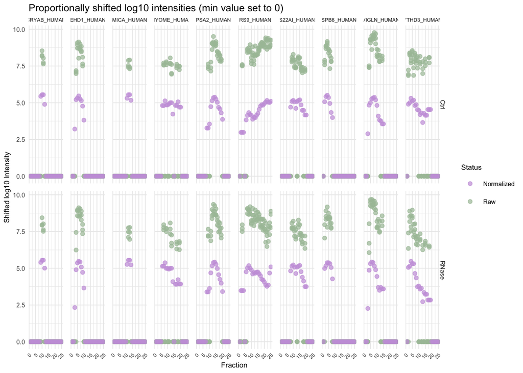

```r
library(ggplot2)
library(scales)

# define color
ctrl_fill_color <- alpha("#A9C1A6", 0.3)
ctrl_line_color <- alpha("#A9C1A6", 1)
rnase_fill_color <- alpha("#c9a0dc", 0.3)
rnase_line_color <- alpha("#c9a0dc", 1)

# 1. Convert raw data to long format
ctrl_long <- df_ctrl %>%
  pivot_longer(cols = -Protein_Name, names_to = "Sample", values_to = "Intensity") %>%
  separate(Sample, into = c("Fraction", "Condition", "Replicate"), sep = "_", extra = "drop") %>%
  mutate(
    Fraction = as.integer(sub("Fraction", "", Fraction)),
    Condition = "Ctrl",
    Status = "Raw",
    Intensity = as.numeric(Intensity)
  )

rnase_long <- df_rnase %>%
  pivot_longer(cols = -Protein_Name, names_to = "Sample", values_to = "Intensity") %>%
  separate(Sample, into = c("Fraction", "Condition", "Replicate"), sep = "_", extra = "drop") %>%
  mutate(
    Fraction = as.integer(sub("Fraction", "", Fraction)),
    Condition = "RNase",
    Status = "Raw",
    Intensity = as.numeric(Intensity)
  )

raw_all <- bind_rows(ctrl_long, rnase_long)

# 2. Convert normalized data to long format
norm_ctrl_long <- normalized_ctrl_df %>%
  pivot_longer(cols = -Protein, names_to = "Fraction", values_to = "Intensity") %>%
  mutate(
    Fraction = as.integer(sub("Fraction", "", Fraction)),
    Condition = "Ctrl",
    Status = "Normalized",
    Intensity = as.numeric(Intensity)
  ) %>%
  rename(Protein_Name = Protein)

norm_rnase_long <- normalized_rnase_df %>%
  pivot_longer(cols = -Protein, names_to = "Fraction", values_to = "Intensity") %>%
  mutate(
    Fraction = as.integer(sub("Fraction", "", Fraction)),
    Condition = "RNase",
    Status = "Normalized",
    Intensity = as.numeric(Intensity)
  ) %>%
  rename(Protein_Name = Protein)

norm_all <- bind_rows(norm_ctrl_long, norm_rnase_long)

# 3. Combine both datasets
combined <- bind_rows(raw_all, norm_all)

# 4. Determine smallest positive value (for offset)
min_positive <- combined %>%
  filter(!is.na(Intensity), Intensity > 0) %>%
  summarise(min_value = min(Intensity)) %>%
  pull(min_value)

# 5. Replace zero and NA values with the smallest positive value
# Then calculate shifted log10 values (smallest value set to 0)
combined_shifted <- combined %>%
  mutate(
    Intensity_fixed = ifelse(is.na(Intensity) | Intensity <= 0, min_positive, Intensity),
    Intensity_shifted = log10(Intensity_fixed) - log10(min_positive)
  )

# 6. Filter only the first 10 proteins
combined_10_shifted <- combined_shifted %>%
  filter(Protein_Name %in% unique(Protein_Name)[1:10])

# 7. Plot with shifted log10 scale
ggplot(combined_10_shifted, aes(x = Fraction, y = Intensity_shifted, color = Status)) +
  geom_point(alpha = 0.7) +
  scale_color_manual(values = c(
    "Raw" = ctrl_line_color,
    "Normalized" = rnase_line_color
  )) +
  facet_grid(Condition ~ Protein_Name) +
  labs(title = "Proportionally shifted log10 intensities (min value set to 0)",
       x = "Fraction", y = "Shifted log10 Intensity") +
  theme_minimal(base_size = 8) +
  theme(
    axis.text.x = element_text(size = 5, angle = 45, hjust = 1),     # Fraction numbers smaller & angled
    axis.text.y = element_text(size = 6),                            # Y-axis text smaller
    axis.title = element_text(size = 7),                            # Axis titles smaller
    strip.text.x = element_text(size = 5, margin = margin(b = 3)),   # Protein names (x facets) smaller
    strip.text.y = element_text(size = 6, margin = margin(r = 3)),   # y facets smaller
    legend.text = element_text(size = 6),                           # Legend text smaller
    legend.title = element_text(size = 7),                          # Legend title smaller
    panel.spacing.x = unit(0.5, "lines"),                           # Less spacing between x facets
    panel.spacing.y = unit(0.5, "lines")                            # Less spacing between y facets
  )
```

###Batch Effect### (Zoe) Goal: Determine if there is a batch effect and remove it. Batch effect in this case refers to differences in data not related to biological reasons but rather technological faults.

##CONTROL

##load data and creat matrix

```r
# 1. Extract expression data and save it as matrix, delete protein names
ctrl_expr_matrix <- as.matrix(percent_ctrl_df[, -1])
```

##create batch vector

```r
# 1. Extract sample names to create batch labels
LC_sample_names <- colnames(ctrl_expr_matrix)

# 2. Create batch labels out of sample names
#create batches from replicates in order to have comparable batches
LC_batch <- sub(".*_(Rep\\d)", "\\1", LC_sample_names)
LC_batch <- factor(LC_batch, levels = c("Rep1", "Rep2", "Rep3"))

# 3. Assign colors
LC_batch_colors <- c("Rep1" = "#c9a0dc", "Rep2" = "#A9C1A6", "Rep3" = "#F5E1A4")
colors <- LC_batch_colors[as.character(LC_batch)]

#4.shorten labels
short_labels <- gsub("Fraction([0-9]+)_Rep([0-9])", "F\\1_R\\2", colnames(ctrl_expr_matrix))
```

##boxplot ctrl Goal: Visualize data in a boxplot in order to observe first differences

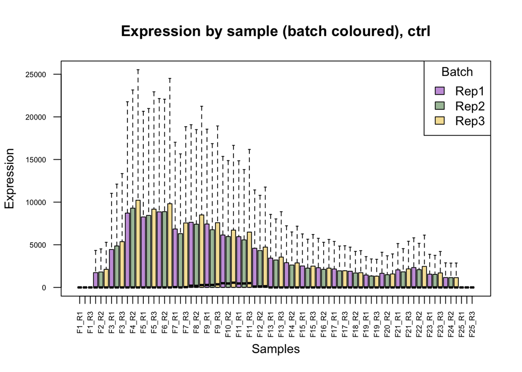

```r
#1. create boxplot
boxplot(ctrl_expr_matrix,
        main = "Expression by sample (batch coloured), ctrl",
        ylab = "Expression",
        xlab = "Samples",
        las = 2,
        col = LC_batch_colors,
        outline = FALSE,
        cex.axis = 0.6,
        names = short_labels)

#2. add key
legend_labels <- levels(LC_batch)
legend_colors <- LC_batch_colors[legend_labels]

legend("topright",
       legend = legend_labels,
       fill = legend_colors,
       title = "Batch")
```